# Econometria II

Mestrado em Administração  
Aula 7

Prof. Washington Santos da Silva

IFMG - Campus Formiga

15 de abril de 2026

## Na aula anterior

**Tópicos**

- Descrição dos Pacotes utilizados
- `tsibble`: estrutura de dados para séries temporais no formato tidy
- Modelos ARIMA e SARIMA
- Metodologia de Box e Jenkins (1970): modelos SARIMA
- Continuação: Avaliação da acurácia de previsões
- Aplicação
- Exercício

## Nesta aula

**Tópicos**

- Passeio Aleatório em Economia/Econometria
- Testes de Raiz Unitária e Estacionariedade
- Exemplo Empírico
- Testes de Raiz Unitária com Quebra Estrutural (se houver tempo)
- Exercício

# Passeio Aleatório em Economia/Econometria

## Passeio Aleatório (*Random Walk*)

**Trabalhos Seminais**

#### Bachelier (1900):

- Trabalho seminal que propôs a versão em tempo contínuo de um passeio aleatório, o movimento browniano, para explicar o comportamento de preços de ações.

#### Samuelson (1965):

- Prova de que, em mercados eficientes, preços de ações seguem um passeio aleatório.
- Base teórica da Hipótese da Eficiência dos Mercados (**HEM**) de Capitais.

#### Fama (1970):

- Popularizou a HEM, mostrando que preços refletem todas as informações disponíveis.
- Conexão direta entre passeio aleatório e imprevisibilidade de preços.

## Artigo Seminal

**Nelson e Plosser (1982)**

O artigo de Nelson e Plosser (1982) teve enorme impacto na Macroeconomia e na Econometria de Séries Temporais ao questionar a visão, então dominante, de que muitas séries macroeconômicas oscilariam em torno de uma **tendência determinística**.

Até então, era comum supor que variáveis como PIB, emprego e produção retornariam à sua trajetória de longo prazo após um choque. Em termos simples, isso equivale à ideia de uma série tendência-estacionária:

$$y_t = \beta_0 + \beta t + \varepsilon_t.$$

Nelson e Plosser argumentaram, com base na análise de séries macroeconômicas dos EUA, que muitas delas eram mais bem descritas como processos com **raiz unitária**, isto é, processos $I(1)$, nos quais os choques têm **efeitos permanentes sobre o nível da série**.

Essa mudança de perspectiva teve consequências profundas:

- reforçou a importância dos **testes de raiz unitária**;
- estimulou o desenvolvimento de métodos para lidar com séries $I(1)$, como a **cointegração**;
- mudou a forma de interpretar os efeitos de choques macroeconômicos no longo prazo.

O artigo também gerou intenso debate, especialmente sobre a possibilidade de confundir raiz unitária com **estacionariedade em torno de tendência com quebra estrutural**.

## Passeio Aleatório (*Random Walk*)

**Definição**

Um **passeio aleatório** simples pode ser definido por:

$$y_t = y_{t-1} + \varepsilon_t,$$

em que:

- $y_t$: valor da variável no tempo $t$;
- $\varepsilon_t$: choque aleatório com $E(\varepsilon_t)=0$ e $V(\varepsilon_t)=\sigma^2$;
- os choques $\varepsilon_t$ são não correlacionados ao longo do tempo.

Uma versão com **deriva** é:

$$y_t = \mu + y_{t-1} + \varepsilon_t.$$

**Interpretação em Finanças**

- Em um mercado eficiente, mudanças de preços decorrem apenas de novas informações.
- Assim, o valor corrente $y_t$ resume toda a informação disponível até o instante $t$.

## Passeio Aleatório (*Random Walk*)

**Melhor Previsão**

Considere o passeio aleatório:

$$y_{t+1} = y_t + \varepsilon_{t+1}.$$

Queremos encontrar a melhor previsão de $y_{t+1}$ com base no conjunto de informações $\Omega_t$, sob o critério de erro quadrático médio:

$$\hat{y}_{t+1}
=
\arg\min_{\hat{y}_{t+1}}
E\left[(y_{t+1}-\hat{y}_{t+1})^2 \mid \Omega_t\right].$$

Sob esse critério, a previsão ótima é a esperança condicional:

$$\hat{y}_{t+1} = E(y_{t+1}\mid \Omega_t).$$

Mas, como

$$y_{t+1} = y_t + \varepsilon_{t+1},$$

segue que:

$$E(y_{t+1}\mid \Omega_t)
=
E(y_t + \varepsilon_{t+1}\mid \Omega_t)
=
y_t + E(\varepsilon_{t+1}\mid \Omega_t).$$

Como $y_t$ é conhecido em $t$ e $E(\varepsilon_{t+1}\mid \Omega_t)=0$, obtemos:

$$E(y_{t+1}\mid \Omega_t)=y_t.$$

Portanto, a melhor previsão para $y_{t+1}$, dado $\Omega_t$, é:

$$\hat{y}_{t+1}=y_t.$$

## Expansão Recursiva

**O caso do passeio aleatório**

A **expansão recursiva** consiste em substituir sucessivamente as defasagens de $y_t$ até escrever a variável atual apenas em função de $y_0$ e dos choques.

Considere o passeio aleatório:

$$y_t = y_{t-1} + \varepsilon_t.$$

Substituindo $y_{t-1}$ pela equação no período anterior:

$$y_t = (y_{t-2} + \varepsilon_{t-1}) + \varepsilon_t
= y_{t-2} + \varepsilon_{t-1} + \varepsilon_t.$$

Fazendo o mesmo mais uma vez:

$$y_t = (y_{t-3} + \varepsilon_{t-2}) + \varepsilon_{t-1} + \varepsilon_t
= y_{t-3} + \varepsilon_{t-2} + \varepsilon_{t-1} + \varepsilon_t.$$

Seguindo esse padrão até chegar em $y_0$, obtemos:

$$y_t = y_0 + \varepsilon_1 + \varepsilon_2 + \cdots + \varepsilon_t
= y_0 + \sum_{i=1}^{t}\varepsilon_i.$$

Logo, o valor atual da série é o valor inicial somado a todos os choques já ocorridos.

**Interpretação**

- cada choque altera o nível da série;
- esses efeitos se acumulam ao longo do tempo;
- por isso, no passeio aleatório, os choques têm efeito **permanente**.
- isso explica por que a trajetória da série pode se afastar persistentemente do valor inicial ao longo do tempo.

## Estacionariedade e Testes de Raiz Unitária

**Por que isso importa?**

Distinguir entre séries **estacionárias** e **não estacionárias** é essencial em econometria de séries temporais.

- Se a série possui **raiz unitária**, choques podem ter efeitos permanentes sobre seu nível.
- Se a série é **estacionária**, choques tendem a se dissipar ao longo do tempo.
- Além disso, trabalhar com séries não estacionárias em regressões pode levar a **regressões espúrias**, com $R^2$ elevado e coeficientes aparentemente significativos, mesmo quando as variáveis não possuem relação econômica genuína.
- Por isso, antes de especificar modelos e interpretar relações de longo prazo, precisamos investigar se a série é compatível com **estacionariedade** ou com a presença de **raiz unitária**.

## Tipos de Não-Estacionariedade

**Duas Formas Importantes**

Na prática, duas formas de não-estacionariedade são especialmente relevantes em econometria de séries temporais:

#### 1. Tendência determinística

$$y_t = \alpha + \beta t + \varepsilon_t$$

- a série oscila em torno de uma tendência linear;
- a não-estacionariedade decorre da presença da tendência $\beta t$.

#### 2. Tendência estocástica

$$y_t = \mu + y_{t-1} + \varepsilon_t$$

- a série segue um passeio aleatório com deriva;
- a não-estacionariedade decorre da **acumulação de choques** ao longo do tempo.

Esses dois casos exigem tratamentos diferentes, o que torna importante distingui-los empiricamente.

## Removendo a Não-Estacionariedade

**Tratamentos Diferentes**

As duas formas de não-estacionariedade exigem tratamentos distintos.

#### 1. Se a série tem tendência determinística

$$y_t = \alpha + \beta t + \varepsilon_t$$

então a estacionariedade pode ser obtida removendo-se a tendência determinística, isto é, por meio de **de-trending**.

#### 2. Se a série tem tendência estocástica

$$y_t = \mu + y_{t-1} + \varepsilon_t$$

então a não-estacionariedade decorre da raiz unitária, e o tratamento adequado é a **primeira diferença**:

$$\Delta y_t = y_t - y_{t-1} = \mu + \varepsilon_t.$$

Portanto, antes de transformar uma série, precisamos entender **qual tipo de não-estacionariedade** está presente.

## Tendência Estocástica e Persistência de Choques

**Por que a raiz unitária é importante?**

Considere o processo AR(1):

$$y_t = \phi y_{t-1} + \varepsilon_t.$$

Aplicando substituições sucessivas, obtemos:

$$y_t = \phi^t y_0 + \sum_{j=0}^{t-1} \phi^j \varepsilon_{t-j}.$$

Essa expressão ajuda a interpretar o efeito dos choques:

- se $|\phi| < 1$, então $\phi^j \to 0$ quando $j$ cresce, e os efeitos dos choques se dissipam ao longo do tempo;
- se $\phi = 1$, obtemos um passeio aleatório:

$$y_t = y_0 + \sum_{i=1}^{t} \varepsilon_i,$$

de modo que os choques se **acumulam** e seus efeitos são **permanentes**;

- se $\phi > 1$, os choques tornam-se progressivamente mais influentes, caracterizando um processo explosivo.

Nesta disciplina, o caso mais importante será $\phi = 1$.

## Passeio Aleatório com Deriva

**Por que remover a tendência não resolve a tendência estocástica?**

Considere o passeio aleatório com deriva:

$$y_t = \mu + y_{t-1} + \varepsilon_t.$$

Expandindo recursivamente, temos:

$$y_t = y_0 + t\mu + \sum_{i=1}^{t} \varepsilon_i.$$

Essa decomposição mostra dois componentes:

- um componente **determinístico**, dado por $t\mu$;
- um componente **estocástico acumulado**, dado por $\sum_{i=1}^{t} \varepsilon_i$.

Se removermos apenas uma tendência linear, eliminamos o termo $t\mu$, mas **não** eliminamos a soma acumulada dos choques.

Portanto, o problema fundamental da não-estacionariedade continua presente.

- Em um passeio aleatório com deriva, **remover a tendência não basta**;
- o tratamento adequado é a **primeira diferença**.

## Um efeito colateral importante

**O que acontece ao diferenciar uma série com tendência determinística?**

Considere uma série com tendência determinística:

$$y_t = \alpha + \beta t + \varepsilon_t.$$

Aplicando uma primeira diferença:

$$\begin{aligned}
\Delta y_t
&= (\alpha + \beta t + \varepsilon_t)
- (\alpha + \beta (t-1) + \varepsilon_{t-1}) \\
&= \beta + \varepsilon_t - \varepsilon_{t-1}.
\end{aligned}$$

Logo, a série diferenciada passa a ter a forma:

$$\Delta y_t = \beta + \varepsilon_t - \varepsilon_{t-1},$$

ou seja, um processo com componente de **média móvel de ordem 1**.

Assim:

- diferenciar uma série com tendência determinística pode remover a não-estacionariedade em nível;
- mas isso é desnecessário, pois o procedimento mais natural nesse caso é remover a tendência determinística diretamente.

Em outras palavras, **o método correto depende do tipo de tendência**.

## Séries Integradas de Ordem $d$

**Definição**

A discussão anterior mostra que o tratamento de uma série depende de quantas diferenças são necessárias para torná-la estacionária.

Se uma série não estacionária precisa ser diferenciada $d$ vezes para se tornar estacionária, dizemos que ela é **integrada de ordem** $d$, e escrevemos:

$$y_t \sim I(d).$$

Em particular:

- $y_t \sim I(0)$: a série já é estacionária;
- $y_t \sim I(1)$: a série se torna estacionária após **uma** diferenciação;
- $y_t \sim I(2)$: a série se torna estacionária após **duas** diferenciações.

Assim, se

$$y_t \sim I(d),$$

então

$$\Delta^d y_t \sim I(0).$$

Na prática, em finanças e em muitas aplicações econômicas, o caso mais relevante costuma ser a distinção entre séries $I(0)$ e $I(1)$.

## Séries $I(0)$, $I(1)$ e $I(2)$

**Interpretação**

A noção de ordem de integração ajuda a entender como diferentes séries se comportam ao longo do tempo.

- Uma série $I(0)$ já é estacionária.
- Uma série $I(1)$ contém uma raiz unitária e se torna estacionária após uma diferenciação.
- Uma série $I(2)$ contém duas raízes unitárias e exige duas diferenciações para induzir estacionariedade.

Em termos qualitativos:

- séries $I(0)$ tendem a oscilar em torno de uma média estável;
- séries $I(1)$ e $I(2)$ podem exibir trajetórias muito persistentes e afastar-se da média por longos períodos.

Na prática, em muitas aplicações econômicas e financeiras, a distinção mais importante é entre séries $I(0)$ e $I(1)$.

## Comparação Visual entre Processos

**Intuição**

Antes de introduzir os testes formais de raiz unitária, vale comparar visualmente alguns processos básicos.

A inspeção visual não substitui os testes, mas ajuda a desenvolver intuição sobre:

- séries **estacionárias**;
- séries com **tendência determinística**;
- séries com **tendência estocástica**.

Nos próximos slides, veremos exemplos desses diferentes comportamentos.

## Processo Ruído Branco

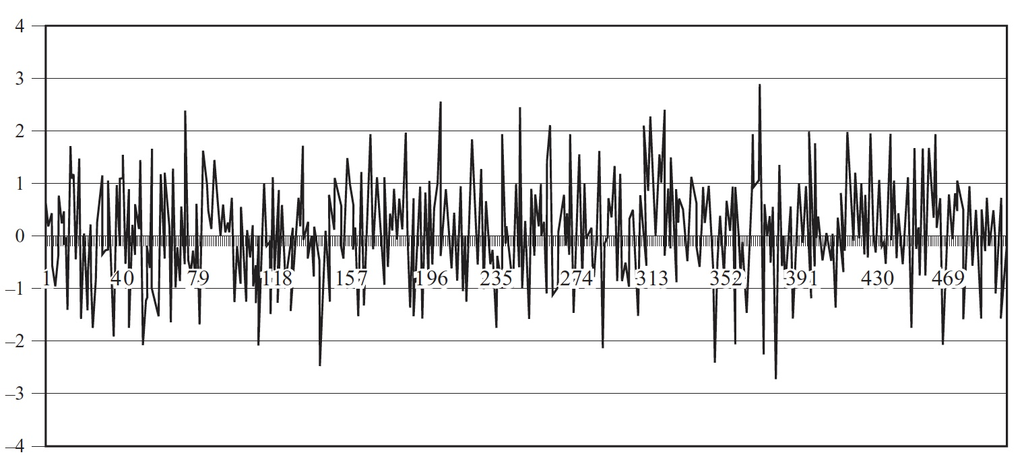

Um processo de ruído branco é estacionário, não exibe tendência e oscila em torno de média constante, cruzando-a com frequência.

## Processo com Tendência Determinística

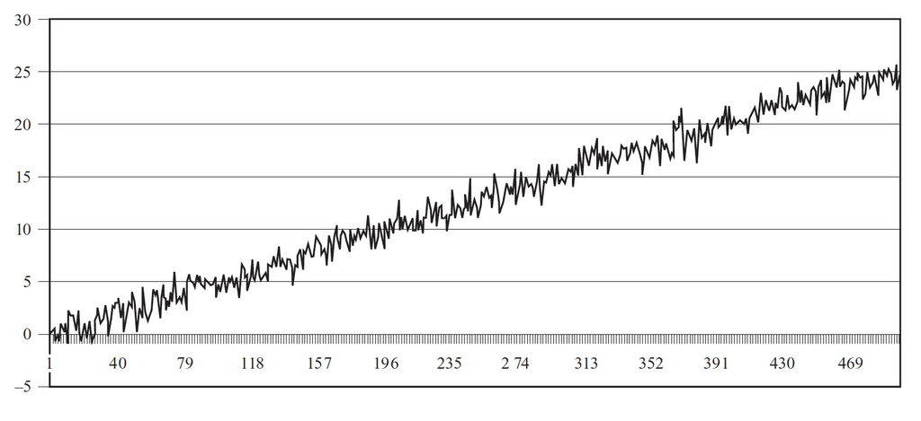

Esse processo exibe uma tendência determinística ascendente, com flutuações aleatórias em torno dela. Se a tendência for removida, a série remanescente pode ser estacionária.

## Passeio Aleatório

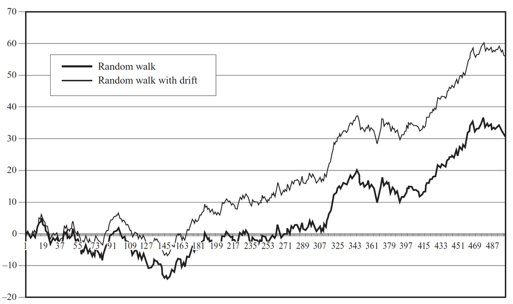

Processos passeio aleatório, com e sem deriva, exibem trajetórias muito persistentes e raramente retornam a um nível médio. A presença de deriva positiva faz a série tender a crescer ao longo do tempo.

## Processo AR(1)

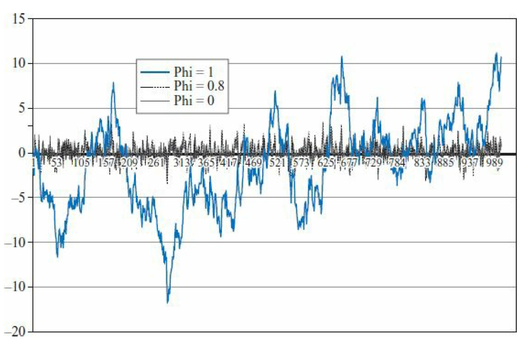

Processos AR(1), $y_t = \phi y_{t-1} + \varepsilon_t$, com: (i) $\phi = 0$ (ruído branco), (ii) $\phi = 0.8$ (processo estacionário) e (iii) $\phi = 1$ (passeio aleatório).

## Limites da Inspeção Visual

**Por que precisamos de testes formais?**

A comparação visual ajuda a desenvolver intuição, mas ela **não é suficiente** para decidir, com segurança, se uma série é:

- estacionária;
- tendência-estacionária; ou
- diferença-estacionária.

Em particular, séries altamente persistentes podem parecer não estacionárias em amostras finitas, mesmo quando são estacionárias.

Por isso, precisamos de **testes formais de raiz unitária** para avaliar se os dados são mais compatíveis com:

- uma série **$I(0)$**, em que choques tendem a se dissipar; ou
- uma série **$I(1)$**, em que choques podem ter efeitos permanentes.

A partir daqui, começaremos com o teste clássico de **Dickey–Fuller**.

# Testes de Raiz Unitária e Estacionariedade

## Uma observação importante

**Funções prontas não substituem fundamentação teórica**

Os testes de raiz unitária ilustram muito bem um ponto central desta disciplina: **dispor de uma função pronta em software não significa saber aplicar corretamente um procedimento econométrico**.

No caso desses testes, o usuário/pesquisador precisa compreender, entre outros aspectos:

- as hipóteses nula e alternativa;
- o papel dos componentes determinísticos;
- a escolha do número de defasagens;
- a diferença entre ADF, Phillips–Perron e KPSS;
- a distribuição não padrão das estatísticas de teste;
- as limitações dos testes em amostras finitas;
- o possível efeito de quebras estruturais.

O software executa os cálculos, mas **não substitui o juízo teórico e econométrico** necessário para especificar, aplicar e interpretar os testes de forma adequada.

Por isso, uma boa base teórica continua sendo indispensável mesmo quando usamos funções prontas.

## Teste de Dickey e Fuller (1979)

**Parte I**

O trabalho inicial e pioneiro sobre testes de raiz unitária em séries temporais foi realizado por Dickey e Fuller (1979).

Considere um modelo autorregressivo de ordem 1:

$$y_t = \phi y_{t-1} + \varepsilon_t, \quad y_0 = 0, \quad \varepsilon_t \sim \text{iid } N(0, \sigma^2)
\tag{1}$$

O estimador de MQ de $\phi$ é então:

$$\hat{\phi} = \frac{\sum_{t=1}^{T} y_{t-1}y_t}{\sum_{t=1}^{T} y_{t-1}^2}
\tag{2}$$

Como já vimos, basta tomar $\phi = 1$ na Eq. 1 para obter um passeio aleatório. Subtraindo $y_{t-1}$ de ambos os lados de Eq. 1, obtemos:

$$\Delta y_t = (\phi - 1)y_{t-1} + \varepsilon_t
\tag{3}$$

O método mais direto para verificar a existência de uma raiz unitária na Eq. 1 é, portanto, testar:

$$\begin{aligned}
H_0: \phi - 1 &= 0 \quad (\text{não estacionária}) \\
H_A: \phi - 1 &< 0 \quad (\text{estacionária})
\end{aligned}$$

Como $y_t = y_{t-1} + \Delta y_t$, segue da Eq. 2 que:

$$\hat{\phi}
= \frac{\sum_{t=1}^{T} y_{t-1}(y_{t-1} + \Delta y_t)}
{\sum_{t=1}^{T} y_{t-1}^2}
= 1 + \frac{\sum_{t=1}^{T} y_{t-1}\Delta y_t}
{\sum_{t=1}^{T} y_{t-1}^2}$$

Logo,

$$\hat{\phi} - 1
= \frac{\sum_{t=1}^{T} y_{t-1}\Delta y_t}
{\sum_{t=1}^{T} y_{t-1}^2}
= \frac{\sum_{t=1}^{T} y_{t-1}\varepsilon_t}
{\sum_{t=1}^{T} y_{t-1}^2}$$

Sob $H_0$, a estatística de teste é dada por:

$$z = T(\hat{\phi} - 1)
= T\frac{\sum_{t=1}^{T} y_{t-1}\varepsilon_t}{\sum_{t=1}^{T} y_{t-1}^2}
= \frac{T^{-1}\sum_{t=1}^{T} y_{t-1}\varepsilon_t}{T^{-2}\sum_{t=1}^{T} y_{t-1}^2}$$

O problema agora é determinar a distribuição limite de $T(\hat{\phi} - 1)$ sob a hipótese nula de que a série é $I(1)$, isto é, possui raiz unitária.

De imediato, podemos dizer que a estatística z não segue uma distribuição conhecida, como a normal, qui-quadrado, t-Student, etc.

## Movimento Browniano Padrão

**Intuição**

Para entender a distribuição assintótica do teste de Dickey–Fuller, é útil ter em mente a ideia de **movimento browniano padrão**, denotado por $B(t)$.

- Trata-se de um processo em **tempo contínuo** que começa em zero: $B(0)=0$;
- seus incrementos são **independentes**;
- para $s,t \geq 0$, o incremento $B(t+s)-B(s)$ tem distribuição normal com média zero e variância $t$:

$$B(t+s)-B(s) \sim N(0,t)$$

- suas trajetórias são contínuas, mas muito irregulares.

Intuitivamente, o movimento browniano padrão pode ser visto como o **limite contínuo de um passeio aleatório reescalado**.

É por isso que, sob a hipótese nula de raiz unitária, a estatística do teste de Dickey–Fuller converge para funcionais de $B(t)$, e não para distribuições usuais como a normal ou a $t$ de Student.

## Movimento Browniano Padrão: Simulação em R

```r
# Fixamos a semente para garantir reprodutibilidade
set.seed(123)

# Intervalo total de tempo [0, t_final] e número de passos
# (usamos t_final ao invés de T para não mascarar T = TRUE de R)
t_final <- 1
n <- 500

# Comprimento de cada passo: dt = t_final / n
# Quanto maior n, mais fina a aproximação do tempo contínuo
dt <- t_final / n

# Grade de tempo: 0, dt, 2dt, ..., t_final
tempo <- seq(0, t_final, length.out = n + 1)

# Número de trajetórias independentes a simular
n_traj <- 5

# Matriz para armazenar as trajetórias:
# cada coluna é uma trajetória, cada linha um instante de tempo
B <- matrix(0, nrow = n + 1, ncol = n_traj)

# Simulação das trajetórias
for (j in 1:n_traj) {

  # Incrementos independentes: dB ~ N(0, dt)
  # Usamos sd = sqrt(dt) porque a variância é dt,
  # logo o desvio padrão é sqrt(dt)
  incrementos <- rnorm(n, mean = 0, sd = sqrt(dt))

  # B(t_k) = soma dos incrementos até t_k
  # O 0 inicial garante B(0) = 0
  B[, j] <- c(0, cumsum(incrementos))
}
```

## Movimento Browniano Padrão simulado

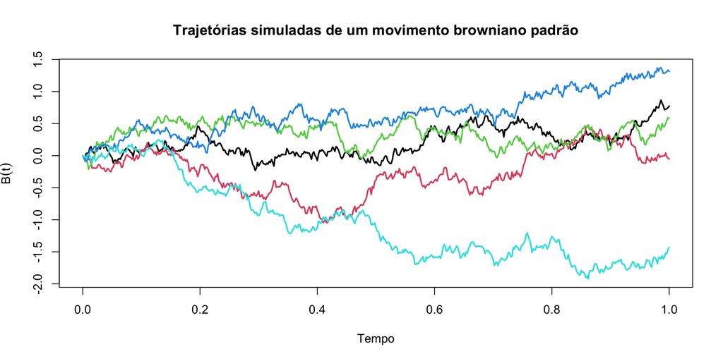

Cada trajetória começa em $B(0)=0$ e evolui como a soma acumulada de pequenos incrementos aleatórios independentes, com média zero e variância proporcional ao intervalo de tempo. Assim, o movimento browniano padrão pode ser visto como uma versão em tempo contínuo de um passeio aleatório reescalado.

## Teste de Dickey e Fuller (1979)

**Parte I (continuação)**

A proposição 1 que nos diz qual é a distribuição limite da estatística $z$ do teste de Dickey-Fuller é:

**Proposição 1.** Seja o passeio aleatório sem deriva $y_t = y_{t - 1} + \varepsilon_t$, em que $y_0 = 0$ e $\varepsilon_t \sim \text{iid } N(0, \sigma^2)$. Sob a **hipótese nula de não estacionariedade**, a estatística de teste $z$ converge em distribuição para uma **distribuição de Dickey–Fuller** (denotada por $DF_{\rho}$):

$$z = T (\hat{\phi} - 1)
= \frac{T^{-1}\sum_{t=1}^{T} y_{t-1}\varepsilon_t}{T^{-2}\sum_{t=1}^{T} y_{t-1}^2}
\xrightarrow{d} DF_{\rho}
= \frac{\frac{1}{2}\left[B(1)^2 - 1\right]}{\int_0^1 [B(r)]^2\,dr}$$

A distribuição de Dickey–Fuller envolve o quadrado do movimento browniano no numerador e um funcional desse processo no denominador (um funcional é uma função que toma outra função como argumento.)

O subscrito $\rho$ em $DF_{\rho}$ é apenas uma notação usada na literatura para identificar essa distribuição assintótica não padrão. Aqui, ele **não** representa um coeficiente de correlação nem um novo parâmetro do modelo.

A distribuição assintótica do teste de Dickey–Fuller é obtida com base no **Teorema Central Funcional do Limite**. Sob $H_0$, o passeio aleatório reescalado converge para um **movimento browniano padrão**; por isso, a estatística do teste converge para um funcional desse processo, e não para distribuições usuais como a normal ou a $t$ de Student.

O termo **funcional** indica que o teorema trata da convergência de **trajetórias inteiras** de processos estocásticos, e não apenas de variáveis aleatórias escalares.

Por **trajetória inteira**, entende-se o **caminho completo** de uma realização do processo ao longo do tempo, e não apenas o seu valor em um único ponto.

Como já dissemos, essa distribuição assintótica não é padrão e só pode ser obtida por métodos de simulação.

## Teste de Dickey e Fuller (1979)

**Parte II**

Alternativamente, na Eq. 3, para testar a hipótese nula de raiz unitária, pode-se aplicar um análogo do teste $t$, isto é, uma estatística construída, como em uma regressão usual, pelo quociente entre o estimador do coeficiente de interesse e seu erro-padrão estimado. A estatística relevante, denotada por $\tau$, é definida por:

$$\tau = \frac{(\hat{\phi} - 1)}{\sigma_{\hat{\phi}}}$$

Com

$$\widehat{\mathrm{Var}}(\hat{\phi})
= \frac{s^2}{\sum_{t=1}^{T} y_{t-1}^2}
\qquad \text{e} \qquad
\sigma_{\hat{\phi}}
= \frac{s}{\left(\sum_{t=1}^{T} y_{t-1}^2\right)^{1/2}},$$

onde

$$s^2 = (T - 1)^{-1} \sum_{t=1}^{T} (y_t - \hat{\phi} y_{t-1})^2.$$

Portanto, levando em conta os elementos anteriores, a estatística de teste alternativa passa a ser:

Substituindo a expressão de $\hat{\phi}-1$ e o erro-padrão estimado, obtemos:

$$\tau
= \frac{\hat{\phi} - 1}{\sigma_{\hat{\phi}}}
= \frac{\displaystyle \frac{\sum_{t=1}^{T} y_{t-1}\varepsilon_t}{\sum_{t=1}^{T} y_{t-1}^2}}
{\displaystyle \frac{s}{\left(\sum_{t=1}^{T} y_{t-1}^2\right)^{1/2}}}
= \frac{\sum_{t=1}^{T} y_{t-1}\varepsilon_t}
{s\left(\sum_{t=1}^{T} y_{t-1}^2\right)^{1/2}}$$

Multiplicando numerador e denominador por $T^{-1}$, segue que:

$$\tau
= \frac{T^{-1}\sum_{t=1}^{T} y_{t-1}\varepsilon_t}
{s\left(T^{-2}\sum_{t=1}^{T} y_{t-1}^2\right)^{1/2}}$$

A Proposição 2 apresenta a distribuição assintótica dessa estatística alternativa.

**Proposição 2.** Seja o passeio aleatório sem deriva $y_t = y_{t-1} + \varepsilon_t$, em que $y_0 = 0$ e $\varepsilon_t \sim \text{iid } N(0, \sigma^2)$. Sob a hipótese nula de não estacionariedade, a estatística de teste $\tau$ converge em distribuição para uma distribuição de Dickey–Fuller não padrão:

$$\tau
=
\frac{T^{-1}\sum_{t=1}^{T} y_{t-1}\varepsilon_t}
{s\left(T^{-2}\sum_{t=1}^{T} y_{t-1}^2\right)^{1/2}}
\overset{d}{\to}
\frac{\frac{1}{2}\left[B(1)^2 - 1\right]}
{\left(\int_0^1 [B(r)]^2\,dr\right)^{1/2}}$$

Essa distribuição também é expressa em termos de funcionais de um movimento browniano.

Ela difere da distribuição assintótica de $z$ pela presença de uma raiz quadrada no denominador e, assim como ela, é obtida por simulação.

## Teste de Dickey e Fuller (1979)

**Desenvolvimentos do Teste de Dickey-Fuller**

**Incluindo Deriva e Tendência Determinística**

No entanto, formas mais gerais para $y_t$ são possíveis, notadamente com a inclusão de uma **deriva** (*drift*) e/ou de uma **tendência determinística**.

As regressões de teste correspondentes são:

$$\begin{aligned}
\Delta y_t &= \mu + (\phi - 1)y_{t-1} + \varepsilon_t \\
\Delta y_t &= \mu + \gamma t + (\phi - 1)y_{t-1} + \varepsilon_t
\end{aligned}$$

Nessas especificações, $\mu$ representa o termo de **deriva** (isto é, uma constante na regressão de teste) e $\gamma t$ representa uma tendência determinística linear.

Em ambos os casos, a hipótese nula continua sendo:

$$H_0: \phi - 1 = 0$$

isto é, a hipótese de **raiz unitária**.

As estatísticas de teste correspondentes são denotadas por $z_c$ e $z_{ct}$: o subscrito $c$ indica a presença de constante, e o subscrito $ct$ indica a presença conjunta de constante e tendência.

A inclusão de componentes determinísticos modifica a regressão de teste e, consequentemente, também altera a distribuição assintótica da estatística sob $H_0$.

Ainda podemos reescrever o segundo desses modelos de forma mais compacta, utilizando notação vetorial:

$$\Delta y_t = \mathbf{s}_t' \boldsymbol{\delta} + (\phi - 1)y_{t-1} + \varepsilon_t$$

com

$$\mathbf{s}_t' = (1, t)
\qquad \text{e} \qquad
\boldsymbol{\delta} = (\mu, \gamma)'.$$

O resultado assintótico correspondente pode então ser enunciado da seguinte forma:

**Proposição 3.** Sob a hipótese nula de raiz unitária, e, portanto, de não estacionariedade, a estatística $z_{ct}$ converge em distribuição para uma distribuição de Dickey–Fuller correspondente ao caso com constante e tendência determinística:

$$z_{ct} = T(\hat{\phi} - 1) \overset{d}{\to} DF_{ct}$$

O símbolo $DF_{ct}$ indica que a distribuição assintótica depende da presença de constante e tendência na regressão de teste.

Essa distribuição difere das anteriormente apresentadas, embora também seja expressa em termos de funcionais do movimento browniano. Assim como nos casos anteriores, ela é obtida por simulação.

## Teste de Dickey-Fuller Aumentado

**Dickey e Fuller (1981)**

Uma segunda extensão do teste DF consiste em permitir a **presença de autocorrelação no termo de erro**, o que corresponde bem ao perfil de uma série econômica típica.

A regressão de teste ADF pode ser escrita, na parametrização em diferenças, como:

$$\Delta y_t = \mathbf{s}_t' \boldsymbol{\delta} + \phi_0 y_{t-1}
+ \sum_{j=1}^{p} \beta_j \Delta y_{t-j} + \varepsilon_t$$

em que $\mathbf{s}_t'$ representa os componentes determinísticos (por exemplo, nenhum termo, constante, ou constante e tendência).

Os termos defasados de $\Delta y_t$ são incluídos para absorver a autocorrelação serial de curto prazo e tornar os resíduos da regressão aproximadamente não autocorrelacionados.

É a inclusão desses termos que justifica a denominação teste de Dickey–Fuller Aumentado (ADF, de *Augmented Dickey–Fuller*).

Quando $p = 0$, o teste ADF se reduz ao teste de Dickey–Fuller simples.

A hipótese nula continua sendo a de **raiz unitária**. Nessa parametrização, ela pode ser escrita como:

$$H_0: \phi_0 = 0$$

As duas estatísticas de teste correspondentes são então dadas por:

$$\begin{aligned}
\tau_{ADF} &= \frac{\hat{\phi}_0}{\sigma_{\hat{\phi}_0}} \\
z_{ADF} &= \frac{T \hat{\phi}_0}{\left(1 - \sum_{j=1}^{p} \beta_j\right)}
\end{aligned}$$

Sob a hipótese nula de raiz unitária e supondo uma escolha apropriada de $p$, as distribuições assintóticas dessas estatísticas são, para a mesma escolha dos regressores determinísticos em $\mathbf{s}_t'$, idênticas às distribuições de Dickey–Fuller obtidas no caso simples correspondente.

Assim, a distribuição assintótica relevante depende da escolha dos componentes determinísticos incluídos na regressão: nenhum termo, constante, ou constante e tendência.

## Teste de Dickey-Fuller Aumentado

**Dificuldades de implementação**

Do ponto de vista prático, a implementação de um teste ADF envolve duas decisões importantes:

#### 1. Quais componentes determinísticos devem ser incluídos na regressão?

A escolha de $\mathbf{s}_t'$ envolve decidir se a regressão deve conter nenhum termo determinístico, apenas uma constante, ou uma constante e uma tendência linear. Essa decisão deve ser guiada pelo gráfico da série, pelo conhecimento do fenômeno econômico em estudo e por especificações econometricamente plausíveis, pois uma escolha inadequada pode reduzir o poder do teste.

#### 2. Quantas defasagens devem ser incluídas na regressão?

A ideia é incluir defasagens em número suficiente para que os resíduos da regressão ADF fiquem aproximadamente não autocorrelacionados. A frequência dos dados pode fornecer uma indicação inicial para a escolha do número máximo de defasagens, mas, na prática, essa decisão costuma ser refinada com base em critérios de informação (como veremos) ou procedimentos sequenciais de seleção.

Em resumo, a implementação do teste ADF exige decidir:

1. quais componentes determinísticos incluir; e
2. quantas defasagens acrescentar para controlar a autocorrelação serial.

## Especificações e Estatísticas do Teste ADF

**Diferentes Especificações**

- Na saída da função `ur.df()` do pacote `urca`, o teste de Dickey–Fuller Aumentado é reportado por meio de estatísticas do tipo $\tau$ e $\phi$.
- Essas estatísticas dependem da especificação da regressão de teste: sem componentes determinísticos, com constante, ou com constante e tendência.
- Em particular, as estatísticas do tipo $\tau$ estão associadas ao teste sobre o coeficiente da variável defasada em nível. Já as estatísticas do tipo $\phi$ correspondem a testes conjuntos de restrições que dependem da especificação adotada.
- Os três casos abaixo descrevem, em nível, as hipóteses nula e alternativa associadas a essas diferentes especificações.

**Caso 1**: sem constante e sem tendência

H$_0$: $y_t = y_{t-1} + \varepsilon_t$

H$_1$: $y_t = \phi y_{t-1} + \varepsilon_t, \quad \phi < 1$

Este é um teste para um passeio aleatório contra um processo AR(1) estacionário.

**Caso 2**: com constante

H$_0$: $y_t = y_{t-1} + \varepsilon_t$

H$_1$: $y_t = \mu + \phi y_{t-1} + \varepsilon_t, \quad \phi < 1$

Este é um teste para um passeio aleatório contra um AR(1) estacionário com deriva.

**Caso 3**: com constante e tendência

H$_0$: $y_t = y_{t-1} + \varepsilon_t$

H$_1$: $y_t = \mu + \phi y_{t-1} + \lambda t + \varepsilon_t, \quad \phi < 1$

Este é um teste para um passeio aleatório contra um AR(1) estacionário com deriva e tendência determinística linear.

- Na saída do `ur.df()`, é comum encontrar:
  - `tau1` no caso sem componentes determinísticos;
  - `tau2` e `phi1` no caso com constante;
  - `tau3`, `phi2` e `phi3` no caso com constante e tendência.

## Testes de DF Aumentado $\tau$

**Teste $\tau$**

- Foco: testar se o coeficiente do termo em nível defasado $y_{t-1}$ na regressão ADF em diferenças é igual a zero.
- Hipóteses:

$$H_0:\gamma = 0
\qquad \text{versus} \qquad
H_A:\gamma < 0$$

Modelo geral:

$$\Delta y_t = \beta_0 + \beta_1 t + \gamma y_{t-1} +
\sum_{i=1}^{p} \alpha_i \Delta y_{t-i} + \varepsilon_t$$

Sendo:

- $y_{t-1}$: valor defasado da série em nível;
- $\beta_0$: constante (opcional);
- $\beta_1 t$: tendência linear (opcional);
- $\Delta y_{t-i}$: diferenças defasadas, incluídas para lidar com autocorrelação serial;
- $\varepsilon_t$: termo de erro.

**Interpretação:**

- O teste $\tau$ avalia se a estatística associada ao coeficiente de $y_{t-1}$ assume um valor suficientemente negativo para rejeitar a hipótese nula de raiz unitária.
- Embora tenha a forma de uma estatística análoga à $t$, o teste $\tau$ **não** utiliza a distribuição $t$ de Student usual, mas uma distribuição não padrão do tipo Dickey–Fuller.
- O foco do teste $\tau$ é a raiz unitária. Já as estatísticas do tipo $\phi$, que também podem aparecer na saída do `ur.df()`, estão associadas a testes conjuntos que dependem da especificação adotada.

## Testes de DF Aumentado $\phi$

**Teste $\phi$**

- Foco: apresentar as estatísticas do tipo $\phi$, que aparecem como estatísticas complementares na saída do teste ADF em especificações com componentes determinísticos.
- Na prática, as estatísticas $\phi$ são reportadas pela função `ur.df()` quando a regressão de teste inclui constante ou constante e tendência.

**Modelo Geral:**

O modelo de referência é o mesmo da regressão ADF:

$$\Delta y_t = \beta_0 + \beta_1 t + \gamma y_{t-1} +
\sum_{i=1}^{p} \alpha_i \Delta y_{t-i} + \varepsilon_t$$

Sendo:

- $\beta_0$: constante (opcional);
- $\beta_1 t$: tendência linear (opcional);
- $\gamma y_{t-1}$: termo em nível defasado, associado ao teste $\tau$;
- $\Delta y_{t-i}$: diferenças defasadas, incluídas para lidar com autocorrelação serial;
- $\varepsilon_t$: termo de erro.

**Interpretação:**

- O teste $\tau$ tem foco no coeficiente de $y_{t-1}$, isto é, na presença de raiz unitária.
- Já as estatísticas do tipo $\phi$ estão associadas a testes conjuntos de restrições que dependem da especificação adotada para a regressão ADF.
- Assim, ao interpretar a saída do `ur.df()`, é importante distinguir:
  - estatísticas $\tau$: focadas no termo em nível defasado;
  - estatísticas $\phi$: associadas a restrições conjuntas em modelos com componentes determinísticos.

## Testando Ordens Superiores de Integração

**Procedimento**

Em princípio, uma série pode apresentar mais de uma raiz unitária.

Por exemplo, uma série $I(2)$ precisa ser diferenciada **duas vezes** para se tornar estacionária.

No entanto, em aplicações financeiras, costuma-se considerar que casos com mais de uma raiz unitária são pouco frequentes.

Assim, no contexto desta disciplina, o foco principal continuará sendo a distinção entre séries **$I(0)$** e **$I(1)$**, que é a mais relevante nas aplicações usuais em finanças.

## O Teste de Phillips-Perron

**Phillips e Perron (1988)**

- O teste de Phillips–Perron (PP) constitui uma alternativa aos testes ADF para verificar a presença de raiz unitária.
- A ideia central é semelhante à do teste ADF: testar a hipótese nula de que a série possui raiz unitária.
- No entanto, em vez de incluir defasagens das diferenças na regressão, como no teste ADF, o teste PP corrige a estatística do teste para lidar, de forma robusta, com autocorrelação serial e heterocedasticidade nos resíduos.
- Em muitas aplicações, os testes PP e ADF conduzem a conclusões semelhantes, embora possam diferir em amostras finitas.

## Críticas aos testes DF, ADF e PP

**Descrição**

- Uma crítica importante aos testes DF, ADF e PP é o seu **baixo poder** contra alternativas muito persistentes.
- Em particular, quando o verdadeiro processo é estacionário, mas possui um coeficiente autorregressivo muito próximo de 1, esses testes podem ter dificuldade em rejeitar a hipótese nula de raiz unitária.
- Por exemplo, distinguir entre $\phi = 1$ e $\phi = 0{,}95$ pode ser difícil, especialmente em amostras pequenas.
- Se o verdadeiro processo gerador de dados for

$$y_t = 0{,}95y_{t-1} + \varepsilon_t,$$

então a série é estacionária, e a hipótese nula de raiz unitária deveria ser rejeitada.

- Uma forma de complementar essa análise é utilizar, além dos testes de raiz unitária, um **teste de estacionariedade**.

## Testes de Estacionariedade

**Teste KPSS**

- Diferentemente dos testes ADF e PP, o teste KPSS (Kwiatkowski *et al.*, 1992) parte da hipótese nula de que a série é estacionária.
- Em termos gerais, suas hipóteses podem ser escritas como:

H$_0$: $y_t$ é estacionária

H$_1$: $y_t$ é não estacionária

- Assim, podemos comparar seus resultados com os obtidos pelos testes ADF e PP, cuja hipótese nula é a de **raiz unitária**.
- Uma comparação:

| Testes ADF / PP | Teste KPSS |
| --- | --- |
| H$_0$: raiz unitária | H$_0$: estacionariedade |
| H$_1$: estacionariedade | H$_1$: não estacionariedade |

- Quatro resultados são possíveis:
  1. ADF/PP rejeita H$_0$ e KPSS não rejeita H$_0$;
  2. ADF/PP não rejeita H$_0$ e KPSS rejeita H$_0$;
  3. ADF/PP rejeita H$_0$ e KPSS rejeita H$_0$;
  4. ADF/PP não rejeita H$_0$ e KPSS não rejeita H$_0$.
- Nos casos (1) e (2), há evidência mais consistente sobre a natureza da série: no caso (1), ambos apontam para estacionariedade; no caso (2), ambos apontam para não estacionariedade.
- Já os casos (3) e (4) devem ser interpretados com cautela, pois podem refletir conflito entre os testes, baixa potência em amostras finitas ou especificação inadequada.
- Por isso, é comum utilizar conjuntamente testes de raiz unitária e testes de estacionariedade, de modo a obter evidências complementares.

# Exemplo Empírico

## O pacote `urca`

**Visão geral**

Nesta aula, utilizamos o pacote `urca`, cujo nome vem de *Unit Root and Cointegration Analysis*.

Esse pacote implementa testes clássicos para análise de raiz unitária, estacionariedade e cointegração em séries temporais.

No exemplo empírico desta aula, utilizaremos principalmente:

- `ur.df()`: teste de Dickey–Fuller Aumentado (ADF);
- `ur.pp()`: teste de Phillips–Perron (PP);
- `ur.kpss()`: teste KPSS.

Além de executar os testes, o pacote também fornece:

- estatísticas de teste;
- valores críticos;
- informações sobre o tipo de regressão ou modelo adotado em cada teste.

Assim, o `urca` é um pacote bastante útil para análises de econometria de séries temporais em R.

## Exemplo Empírico

**Preços e Retornos de Casas no Reino Unido**

A ideia deste exemplo é reproduzir, com alterações e ampliações, a seção 16 de Wichmann e Brooks (2019).

Vamos aplicar os testes ADF, Phillips–Perron e KPSS a duas séries mensais relacionadas ao mesmo mercado:

- **preços médios de casas** no Reino Unido;
- **retornos simples** calculados a partir desses preços.

A ideia é verificar se os testes conseguem distinguir uma série em nível, tipicamente mais persistente, de uma série de retornos, que costuma ser mais próxima da estacionariedade.

Neste exemplo, veremos o código básico para:

- importar a série de preços;
- construir a série de retornos;
- aplicar os testes ADF, Phillips–Perron e KPSS às séries de preços e retornos.

## Importação e Preparação dos Dados

```r
# importar a planilha com a série mensal de preços
dados_ukhp <- read_xls(
  here("dados/brutos/UKHP.xls"),
  skip = 1,
  col_types = c("date", "numeric"),
  col_names = c("mes", "precos_casas")
)

# construir a série de retornos simples e
# adiciona o resultado à df
dados_ukhp <- dados_ukhp |>
  mutate(
    ret_casas = c(
      NA,
      100 * diff(precos_casas) / precos_casas[-length(precos_casas)]
    )
  ) |>
  na.omit()
```

## Visualização das Séries

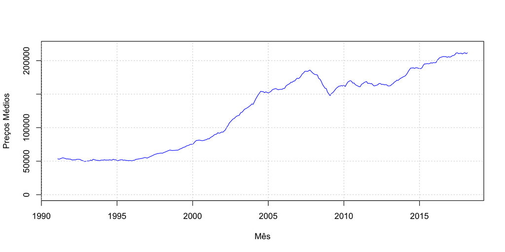

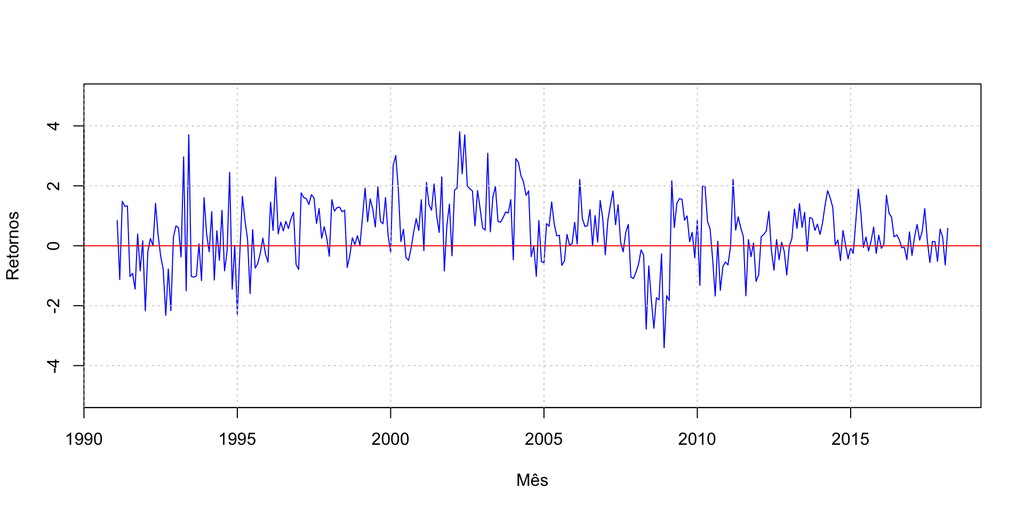

## Nota metodológica

**Nota**

- O tratamento dos `lags` não é o mesmo nos três testes.
- No **teste ADF**, defasagens de $\Delta y_t$ são incluídas explicitamente na regressão de teste para controlar a autocorrelação serial dos resíduos. Na função `ur.df()`, o argumento `lags` define o número **máximo** de defasagens a considerar. Quando combinado com `selectlags = "AIC"` ou `selectlags = "BIC"`, a função seleciona automaticamente o número ótimo de defasagens. Se `selectlags` não for informado, a função usa `selectlags = "Fixed"`, incluindo todas as defasagens na regressão — o que, em geral, não é recomendado, pois pode reduzir o poder do teste.
- Já nos testes **Phillips–Perron** e **KPSS**, os `lags` não têm esse mesmo papel. Nesses casos, eles estão ligados à estimação não paramétrica da variância de longo prazo<sup>1</sup>, usada para corrigir a estatística de teste diante de autocorrelação e heterocedasticidade.
- Neste exemplo, usamos `lags = 12` e `selectlags = "BIC"` no ADF. Já no Phillips–Perron e no KPSS, ambos usam a mesma regra de Schwert ($\lfloor 4(T/100)^{1/4} \rfloor$) para definir o número de lags: `lags = "short"` é passado explicitamente no PP e corresponde ao valor padrão no KPSS.
[^1]: **variância de longo prazo** significa uma medida de variabilidade que incorpora não apenas a variância contemporânea dos erros, mas também suas autocovariâncias ao longo do tempo

## Teste ADF

**Hipóteses do Teste**

No teste ADF, a hipótese nula é a de **raiz unitária**. Portanto:

- se **não rejeitamos $H_0$**, a evidência é compatível com **não estacionariedade**;
- se **rejeitamos $H_0$**, a evidência é compatível com **estacionariedade**.

**Por que $\tau_3$ para preços e $\tau_2$ para retornos?**

A estatística de teste do ADF depende dos **componentes determinísticos** incluídos na regressão auxiliar:

| Estatística | `type` | Componentes | Uso típico |
| --- | --- | --- | --- |
| $\tau_3$ | `"trend"` | constante + tendência | séries com tendência determinística visível |
| $\tau_2$ | `"drift"` | apenas constante | séries que oscilam em torno de uma média |
| $\tau_1$ | `"none"` | nenhum | séries com média zero |

Os **valores críticos** mudam de uma estatística para outra, pois as distribuições assintóticas são diferentes. Por isso, cada tipo de regressão tem sua própria tabela de valores críticos.

A escolha do `type` deve se basear na inspeção gráfica da série e no conhecimento teórico sobre o processo gerador dos dados.

## Teste ADF em R

```r
# preços em nível: o gráfico sugere tendência determinística
adf_precos <- ur.df(
  y = dados_ukhp$precos_casas,
  type = "trend",
  lags = 12,
  selectlags = "BIC"
)

# exibe o resultado
summary(adf_precos)
```

```
###############################################
# Augmented Dickey-Fuller Test Unit Root Test #
###############################################

Test regression trend


Call:
lm(formula = z.diff ~ z.lag.1 + 1 + tt + z.diff.lag)

Residuals:
    Min      1Q  Median      3Q     Max
-4702.4  -600.0   -29.6   617.9  4581.8

Coefficients:
              Estimate Std. Error t value Pr(>|t|)
(Intercept) 386.381476 186.530862   2.071   0.0392 *
z.lag.1      -0.007554   0.004239  -1.782   0.0758 .
tt            4.571442   2.597456   1.760   0.0794 .
z.diff.lag1   0.324588   0.054424   5.964 6.74e-09 ***
z.diff.lag2   0.294158   0.054572   5.390 1.40e-07 ***
---
Signif. codes:  0 '***' 0.001 '**' 0.01 '*' 0.05 '.' 0.1 ' ' 1

Residual standard error: 1191 on 308 degrees of freedom
Multiple R-squared:  0.2831,    Adjusted R-squared:  0.2738
F-statistic:  30.4 on 4 and 308 DF,  p-value: < 2.2e-16


Value of test-statistic is: -1.7819 3.5506 1.6047

Critical values for test statistics:
      1pct  5pct 10pct
tau3 -3.98 -3.42 -3.13
phi2  6.15  4.71  4.05
phi3  8.34  6.30  5.36
```

```r
# retornos: a série oscila em torno de uma média aproximadamente constante
adf_retornos <- ur.df(
  y = dados_ukhp$ret_casas,
  type = "drift",
  lags = 12,
  selectlags = "BIC"
)

# exibe o resultado
summary(adf_retornos)
```

```
###############################################
# Augmented Dickey-Fuller Test Unit Root Test #
###############################################

Test regression drift


Call:
lm(formula = z.diff ~ z.lag.1 + 1 + z.diff.lag)

Residuals:
     Min       1Q   Median       3Q      Max
-2.93821 -0.58274 -0.03581  0.50530  2.96090

Coefficients:
            Estimate Std. Error t value Pr(>|t|)
(Intercept)  0.19819    0.06162   3.216  0.00144 **
z.lag.1     -0.42751    0.06013  -7.109 8.08e-12 ***
z.diff.lag  -0.33158    0.05316  -6.237 1.46e-09 ***
---
Signif. codes:  0 '***' 0.001 '**' 0.01 '*' 0.05 '.' 0.1 ' ' 1

Residual standard error: 0.9787 on 310 degrees of freedom
Multiple R-squared:  0.3948,    Adjusted R-squared:  0.3909
F-statistic: 101.1 on 2 and 310 DF,  p-value: < 2.2e-16


Value of test-statistic is: -7.1092 25.2746

Critical values for test statistics:
      1pct  5pct 10pct
tau2 -3.44 -2.87 -2.57
phi1  6.47  4.61  3.79
```

## Teste ADF

**Interpretação dos resultados**

- **Série de preços**

Para a série de **preços em nível**, usamos `type = "trend"`, pois o gráfico sugere tendência determinística.

- estatística `tau3`: $-1.7819$
- valor crítico a 5%: $-3.42$

Como $-1.7819 > -3.42$, **não rejeitamos $H_0$** ao nível de 5%.

**Conclusão**: a série de preços apresenta evidência compatível com **não estacionariedade**.

- **Série de retornos**

Para a série de **retornos**, usamos `type = "drift"`, pois a série oscila em torno de uma média aproximadamente constante, sem tendência determinística clara.

- estatística `tau2`: $-7.1092$
- valor crítico a 1%: $-3.44$

Como $-7.1092 < -3.44$, **rejeitamos $H_0$** ao nível de 1%.

Logo, a série de retornos apresenta forte evidência de **estacionariedade**.

**Observação**

O critério BIC selecionou apenas 2 defasagens para os preços e 1 para os retornos, resultando em regressões parcimoniosas que preservam o poder do teste. Essa parcimônia é desejável, pois a inclusão de defasagens desnecessárias consome graus de liberdade e pode reduzir a capacidade do teste de rejeitar a hipótese nula.

## Teste de Phillips–Perron

**Hipóteses do Teste**

No teste Phillips–Perron, a hipótese nula também é a de **raiz unitária**. Portanto:

- se **não rejeitamos $H_0$**, a evidência é compatível com **não estacionariedade**;
- se **rejeitamos $H_0$**, a evidência é compatível com **estacionariedade**.

**Por que usamos `Z-tau`?**

A função `ur.pp()` permite diferentes estatísticas de teste. Aqui usamos `Z-tau` porque ela corresponde à versão padronizada do teste Phillips–Perron mais diretamente comparável à estatística $\tau$ do teste ADF.

## Teste de Phillips–Perron em R

```r
# preços em nível: com tendência determinística
pp_precos <- ur.pp(
  dados_ukhp$precos_casas,
  type = "Z-tau",
  model = "trend",
  lags = "short"
)
summary(pp_precos)
```

```
##################################
# Phillips-Perron Unit Root Test #
##################################

Test regression with intercept and trend


Call:
lm(formula = y ~ y.l1 + trend)

Residuals:
    Min      1Q  Median      3Q     Max
-5896.9  -738.4   -59.7   741.1  3532.2

Coefficients:
             Estimate Std. Error t value Pr(>|t|)
(Intercept) 1.263e+03  5.964e+02   2.118   0.0349 *
y.l1        9.938e-01  4.757e-03 208.903   <2e-16 ***
trend       4.458e+00  2.846e+00   1.566   0.1183
---
Signif. codes:  0 '***' 0.001 '**' 0.01 '*' 0.05 '.' 0.1 ' ' 1

Residual standard error: 1380 on 322 degrees of freedom
Multiple R-squared:  0.9994,    Adjusted R-squared:  0.9994
F-statistic: 2.692e+05 on 2 and 322 DF,  p-value: < 2.2e-16


Value of test-statistic, type: Z-tau  is: -1.6192

           aux. Z statistics
Z-tau-mu              0.4301
Z-tau-beta            1.7444

Critical values for Z statistics:
                     1pct      5pct     10pct
critical values -3.989951 -3.425196 -3.135412
```

```r
# retornos: com constante, sem tendência
pp_retornos <- ur.pp(
  dados_ukhp$ret_casas,
  type = "Z-tau",
  model = "constant",
  lags = "short"
)
summary(pp_retornos)
```

```
##################################
# Phillips-Perron Unit Root Test #
##################################

Test regression with intercept


Call:
lm(formula = y ~ y.l1)

Residuals:
    Min      1Q  Median      3Q     Max
-3.5840 -0.6247  0.0056  0.6297  3.9634

Coefficients:
            Estimate Std. Error t value Pr(>|t|)
(Intercept)  0.27614    0.06228   4.434 1.27e-05 ***
y.l1         0.35755    0.05195   6.882 3.07e-11 ***
---
Signif. codes:  0 '***' 0.001 '**' 0.01 '*' 0.05 '.' 0.1 ' ' 1

Residual standard error: 1.048 on 323 degrees of freedom
Multiple R-squared:  0.1279,    Adjusted R-squared:  0.1252
F-statistic: 47.36 on 1 and 323 DF,  p-value: 3.072e-11


Value of test-statistic, type: Z-tau  is: -13.1202

         aux. Z statistics
Z-tau-mu            4.7053

Critical values for Z statistics:
                     1pct      5pct     10pct
critical values -3.452235 -2.870604 -2.571567
```

## Teste de Phillips–Perron

**Interpretação dos resultados**

**Série de preços**

Para a série de **preços em nível**, usamos `model = "trend"`, pois o gráfico sugere tendência determinística.

- estatística `Z-tau`: $-1.6192$
- valor crítico a 5%: $-3.4252$

Como $-1.6192 > -3.4252$, **não rejeitamos $H_0$** ao nível de 5%.

**Conclusão**: a série de preços apresenta evidência compatível com **não estacionariedade**.

**Série de retornos**

Para a série de **retornos**, usamos `model = "constant"`, pois a série oscila em torno de uma média aproximadamente constante, sem tendência determinística clara.

- estatística `Z-tau`: $-13.1202$
- valor crítico a 5%: $-2.8706$

Como $-13.1202 < -2.8706$, **rejeitamos $H_0$** ao nível de 5%.

Logo, a série de retornos apresenta evidência compatível com **estacionariedade**.

**Observação**

Os resultados do teste Phillips–Perron são consistentes com os do teste ADF:

- **preços em nível**: evidência de não estacionariedade;
- **retornos**: evidência de estacionariedade.

## Teste de KPSS

**Hipóteses do Teste**

No teste KPSS, a hipótese nula é a de **estacionariedade**. Portanto:

- se **não rejeitamos $H_0$**, a evidência é compatível com **estacionariedade**;
- se **rejeitamos $H_0$**, a evidência é compatível com **não estacionariedade**.

## Teste KPSS em R

```r
# preços em nível: estacionariedade em torno de tendência
kpss_precos <- ur.kpss(
  dados_ukhp$precos_casas,
  type = "tau"
)

# exibe o resultado
summary(kpss_precos)
```

```
#######################
# KPSS Unit Root Test #
#######################

Test is of type: tau with 5 lags.

Value of test-statistic is: 0.5393

Critical value for a significance level of:
                10pct  5pct 2.5pct  1pct
critical values 0.119 0.146  0.176 0.216
```

```r
# retornos: estacionariedade em torno de média constante
kpss_retornos <- ur.kpss(
  dados_ukhp$ret_casas,
  type = "mu"
)

# exibe o resultado
summary(kpss_retornos)
```

```
#######################
# KPSS Unit Root Test #
#######################

Test is of type: mu with 5 lags.

Value of test-statistic is: 0.3802

Critical value for a significance level of:
                10pct  5pct 2.5pct  1pct
critical values 0.347 0.463  0.574 0.739
```

## Teste KPSS

**Interpretação dos resultados**

**Série de preços**

Para a série de **preços em nível**, usamos `type = "tau"`, pois queremos testar estacionariedade em torno de uma tendência determinística.

- estatística KPSS: $0.5393$
- valor crítico a 5%: $0.146$

Como $0.5393 > 0.146$, **rejeitamos $H_0$** ao nível de 5%.

**Conclusão**: a série de preços apresenta evidência compatível com **não estacionariedade**.

**Série de retornos**

Para a série de **retornos**, usamos `type = "mu"`, pois queremos testar estacionariedade em torno de uma média constante.

- estatística KPSS: $0.3802$
- valor crítico a 5%: $0.463$

Como $0.3802 < 0.463$, **não rejeitamos $H_0$** ao nível de 5%.

Logo, a série de retornos apresenta evidência compatível com **estacionariedade** a 5%.

**Observação**

Para os retornos, a hipótese nula de estacionariedade não é rejeitada a 5%, mas seria rejeitada a 10%, pois $0.3802 > 0.347$.

**Síntese dos três testes**

Os três testes conduzem à mesma conclusão empírica:

- **preços em nível**: evidência de não estacionariedade;
- **retornos**: evidência de estacionariedade.

Esse resultado é coerente com a expectativa teórica: séries de preços costumam ser não estacionárias, enquanto séries de retornos tendem a ser estacionárias.

# Testes de Raiz Unitária com Quebras Estruturais

## Testes de Raiz Unitária com Quebras Estruturais

**Descrição**

- Até aqui, consideramos testes de raiz unitária que não incorporam quebras estruturais no processo gerador dos dados.
- No entanto, os testes usuais do tipo Dickey–Fuller podem funcionar mal quando a série apresenta mudanças permanentes no **nível** ou na **tendência**.
- Na presença de quebras estruturais não modeladas, os testes usuais de raiz unitária podem ter **baixo poder contra a alternativa de estacionariedade com quebra estrutural**.
- Além disso, dependendo do contexto e da forma da quebra, esses testes também podem apresentar **distorções de tamanho**, rejeitando a hipótese nula com frequência excessiva.
- Em geral, quanto maior a quebra e menor a amostra, menor tende a ser o poder dos testes usuais.

## Testes de Raiz Unitária com Quebras Estruturais

**Perron (1989)**

- Perron (1989) mostrou que, se permitirmos a presença de quebras estruturais no modelo de teste, várias séries macroeconômicas frequentemente classificadas como não estacionárias podem, na verdade, ser estacionárias em torno de uma tendência com quebra estrutural.
- A ideia central é que uma quebra não modelada pode fazer uma série estacionária parecer mais persistente do que realmente é.
- Em particular, Perron (1989) argumentou que, para várias séries macroeconômicas, uma tendência determinística com quebra pode ser uma descrição mais adequada do que um modelo com raiz unitária sem quebra.

## O Procedimento de Perron (1989)

**Contexto**

Perron (1989) propôs três modelos de teste, dependendo do tipo de quebra estrutural que se acredita estar presente:

1. Um modelo de **crash**, que permite uma quebra no **nível** (intercepto);
2. Um modelo de **mudança de crescimento**, que permite uma quebra na **inclinação** da tendência;
3. Um modelo mais geral, que permite quebra tanto no **nível** quanto na **inclinação**.

Seja $T_b$ a data de quebra. Uma dummy de quebra pode ser definida por:

$$D_t =
\begin{cases}
0, & \text{se } t < T_b \\
1, & \text{se } t \geq T_b
\end{cases}$$

## O Procedimento de Perron (1989)

**Detalhes**

A versão mais geral do teste pode ser escrita como:

$$\Delta y_t = \psi y_{t-1} + \mu + \theta_1 D_t +
\theta_2 (t - T_b)D_t + \lambda t +
\sum_{i=1}^{p} c_i \Delta y_{t-i} + \varepsilon_t$$

em que:

- $\theta_1 D_t$ permite uma **quebra no nível**;
- $\theta_2 (t - T_b)D_t$ permite uma **quebra na inclinação** da tendência;
- $\sum_{i=1}^{p} c_i \Delta y_{t-i}$ é incluído para lidar com autocorrelação serial.

Casos particulares:

- modelo apenas de **crash**: defina $\theta_2 = 0$;
- modelo apenas de **mudança de crescimento**: defina $\theta_1 = 0$.

Uma limitação importante dessa abordagem é que ela pressupõe que a data de quebra $T_b$ seja **conhecida antecipadamente**.

## Extensões de Perron (1989)

**Banerjee, Lumsdaine e Stock (1992) e Zivot e Andrews (1992)**

- Uma crítica importante ao procedimento de Perron (1989) é que seus valores críticos pressupõem que a data de quebra seja escolhida **exogenamente**.
- Na prática, porém, o pesquisador frequentemente identifica a quebra após examinar os dados.
- Quando isso ocorre, a teoria assintótica do teste com quebra exógena deixa de ser apropriada.
- Banerjee, Lumsdaine e Stock (1992) e Zivot e Andrews (1992) seguem uma mesma motivação geral: permitir que a data de quebra seja determinada **endogenamente** a partir dos dados.

## Extensões de Perron (1989)

**Banerjee, Lumsdaine e Stock (1992)**

- Banerjee, Lumsdaine e Stock (1992) propuseram testes **recursivos**, **rolling** e **sequenciais** para investigar raiz unitária e quebra estrutural quando a data da quebra não é conhecida a priori.
- A ideia central é repetir o teste para diferentes datas candidatas de quebra dentro de uma **amostra aparada**, isto é, excluindo as primeiras e as últimas observações.
- Para cada data candidata, estima-se a regressão de teste e calcula-se a estatística correspondente.
- A decisão final baseia-se na estatística mais favorável à rejeição da hipótese nula.

## Extensões de Perron (1989)

**Banerjee, Lumsdaine e Stock (1992)**

Um exemplo de regressão sequencial utilizada nesse contexto é:

$$\Delta y_t = \psi y_{t-1} + \mu + \alpha B_t(\lambda) +
\eta t + \sum_{i=1}^{p} c_i \Delta y_{t-i} + \varepsilon_t$$

em que:

- $\lambda = T_b/T$ representa a fração da amostra em que a quebra ocorre;
- $B_t(\lambda)$ é um termo que permite modelar a quebra para uma data candidata;
- a quebra pode ocorrer no **nível** ou na **tendência**, dependendo da forma escolhida para $B_t(\lambda)$.

Para cada especificação, são necessários valores críticos apropriados.

## Extensões de Perron (1989)

**Zivot e Andrews (1992)**

- Zivot e Andrews (1992) propuseram um teste de raiz unitária com **uma quebra estrutural endógena**, escolhida a partir dos dados.
- O objetivo é procurar, ao longo das datas candidatas de quebra, a evidência mais forte contra a hipótese nula de raiz unitária.
- Assim, o teste de Zivot–Andrews tornou-se uma referência importante quando se suspeita da presença de uma única quebra estrutural no nível e/ou na tendência cuja data não é conhecida antecipadamente.

## Extensões Adicionais

**Perron (1997)**

- Perron (1997) propôs uma extensão em que a data de quebra também é tratada como desconhecida e estimada a partir dos dados.
- Em relação a abordagens anteriores, esse procedimento amplia a flexibilidade do teste ao permitir modelar a quebra estrutural de forma mais geral.
- Em termos práticos, esse tipo de procedimento busca responder à mesma questão central dos testes anteriores: a série possui raiz unitária ou é estacionária em torno de uma estrutura determinística com quebra?

## Testando Raízes Unitárias com Quebras Estruturais

**Exemplo - Taxas de Juros EuroSterling**

- Brooks e Rew (2002) examinaram se as taxas de juros EuroSterling seriam melhor modeladas como processos com raiz unitária ou não, permitindo a possibilidade de quebras estruturais.
- A motivação é que a falha em considerar quebras estruturais, causadas, por exemplo, por mudanças de política monetária, pode levar a inferências incorretas sobre a dinâmica das taxas de juros.
- Os dados incluem taxas EuroSterling de diferentes maturidades, com frequência diária, no período de 1º de janeiro de 1982 a 1º de setembro de 1997.
- Os autores aplicaram testes usuais de raiz unitária, bem como testes recursivos, sequenciais, rolling e procedimentos com quebra estrutural.
- O objetivo é verificar se permitir quebras estruturais altera a conclusão obtida com os testes usuais.

## Resultados de Brooks e Rew (2002)

**Como ler a figura**

- A figura resume os resultados dos testes aplicados às diferentes maturidades, comparando procedimentos usuais e testes com quebra estrutural.

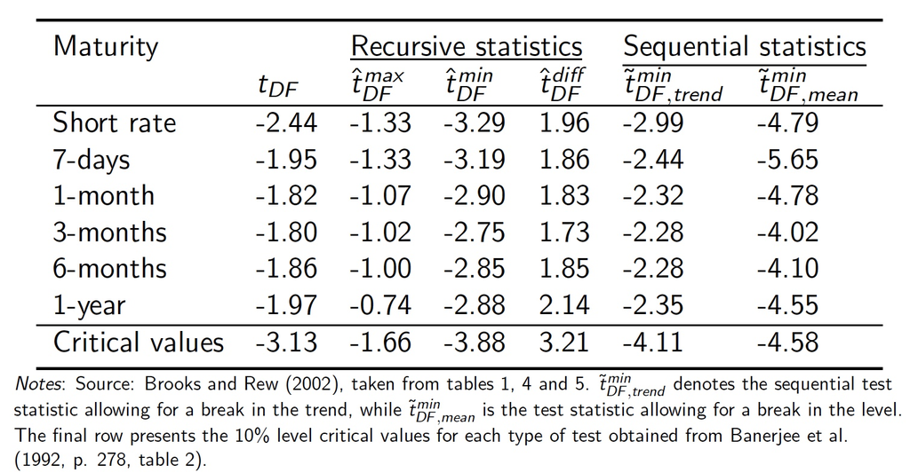

## Síntese

**Os testes de raiz unitária ainda são relevantes?**

- **Sim**, os testes de raiz unitária continuam relevantes na econometria aplicada e em séries temporais (Brien, Jansson e Nielsen, 2024; Herranz, 2017; Müller e Watson, 2024; Skrobotov, 2024).
- Eles ainda são usados para investigar se uma série é compatível com **estacionariedade** ou com a presença de **raiz unitária**, o que é importante para modelagem dinâmica, cointegração e inferência de longo prazo (Brien, Jansson e Nielsen, 2024; Skrobotov, 2024).
- Além disso, a literatura recente continua propondo **novos testes** e **extensões** para lidar com problemas como:
  - baixo poder;
  - distorções de tamanho;
  - quebras estruturais;
  - dependência transversal em painéis;
  - raízes unitárias em contextos espaciais (Glynn, Perera e Verma, 2007; Müller e Watson, 2024; Skrobotov, 2024).
- Portanto, o tema permanece atual, embora hoje se reconheça que os testes devem ser aplicados com **cautela** e interpretados em conjunto com evidências complementares (Glynn, Perera e Verma, 2007).

# Exercício

## Exercício

**AIC vs. BIC na seleção de defasagens do teste ADF**

Nesta aula, aplicamos o teste ADF às séries de preços e retornos de casas no Reino Unido usando `selectlags = "BIC"`. Agora, refaça a análise usando `selectlags = "AIC"` e responda:

1. Execute o teste ADF para ambas as séries (**preços** e **retornos**) com `lags = 12` e `selectlags = "AIC"`. Quantas defasagens o AIC selecionou em cada caso?
2. Compare as estatísticas de teste e as conclusões obtidas com o AIC com aquelas obtidas com o BIC (apresentadas em aula). Houve mudança na conclusão de algum dos testes? Se sim, em qual série e em que direção?
3. Os testes Phillips–Perron e KPSS não dependem da escolha de defasagens da mesma forma que o ADF. Seus resultados mudam? Use-os como referência para avaliar qual critério (AIC ou BIC) produziu resultados mais consistentes no teste ADF.
4. Com base nos resultados, elabore uma explicação sobre por que o critério de seleção de defasagens pode afetar o poder do teste ADF. Relacione sua resposta ao número de parâmetros estimados na regressão de teste.

## Referências

BACHELIER, L. **Théorie de la spéculation**. Paris: Gauthier-Villars, 1900.

BANERJEE, A.; LUMSDAINE, R. L.; STOCK, J. H. Recursive and Sequential Tests of the Unit-Root and Trend-Break Hypotheses: Theory and International Evidence. **Journal of Business and Economic Statistics**, v. 10, n. 3, p. 271–287, 1992.

BOX, G. E. P.; JENKINS, G. M. **Time Series Analysis: Forecasting and Control**. San Francisco: Holden-Day, 1970.

BRIEN, S.; JANSSON, M.; NIELSEN, M. Ø. [Nearly Efficient Likelihood Ratio Tests of a Unit Root in an Autoregressive Model of Arbitrary Order](https://doi.org/10.1017/S0266466622000652). **Econometric Theory**, v. 40, n. 5, p. 1159–1183, 2024.

BROOKS, C. **Introductory Econometrics For Finance**. 4th. ed. [s.l.] Cambridge University Press, 2019.

BROOKS, C.; REW, A. G. Testing for Non-Stationarity and Cointegration Allowing for the Possibility of a Structural Break: An Application to EuroSterling Interest Rates. **Economic Modelling**, v. 19, n. 1, p. 65–90, 2002.

DICKEY, D. A.; FULLER, W. A. Distribution of the estimators for autoregressive time series with a unit root. **Journal of the American Statistical Association**, v. 74, n. 366a, p. 427–431, 1979.

___. Likelihood ratio statistics for autoregressive time series with a unit root. **Econometrica**, v. 49, n. 4, p. 1057–1072, 1981.

FAMA, E. F. Efficient Capital Markets: A Review of Theory and Empirical Work. **Journal of Finance**, v. 25, n. 2, p. 383–417, 1970.

GLYNN, J.; PERERA, N.; VERMA, R. Unit Root Tests and Structural Breaks: A Survey with Applications. **Journal of Quantitative Methods for Economics and Business Administration**, v. 3, n. 1, p. 63–79, 2007.

HERRANZ, E. [Unit root tests](https://doi.org/10.1002/wics.1396). **WIREs Computational Statistics**, v. 9, n. 6, p. e1396, 2017.

HILL, R. C.; GRIFFITHS, W. E.; JUDGE, G. G. **Econometria**. 3. ed. São Paulo: Saraiva, 2003.

KWIATKOWSKI, D. *et al.* Testing the null hypothesis of stationarity against the alternative of a unit root. **Journal of Econometrics**, v. 54, n. 1-3, p. 159–178, 1992.

MORETTIN, P. A. **Econometria Financeira: um curso em séries temporais e financeiras**. 2. ed. São Paulo: Edgard Blücher, 2011.

MÜLLER, U. K.; WATSON, M. W. [Spatial Unit Roots and Spurious Regression](https://doi.org/10.3982/ECTA21654). **Econometrica**, v. 92, n. 5, p. 1661–1695, 2024.

NELSON, C. R.; PLOSSER, C. I. Trends and Random Walks in Macroeconomic Time Series: Some Evidence and Implications. **Journal of Monetary Economics**, v. 10, n. 2, p. 139–162, 1982.

PERRON, P. The Great Crash, the Oil Price Shock, and the Unit Root Hypothesis. **Econometrica**, v. 57, n. 6, p. 1361–1401, 1989.

___. Further Evidence on Breaking Trend Functions in Macroeconomic Variables. **Journal of Econometrics**, v. 80, n. 2, p. 355–385, 1997.

PHILLIPS, P. C. B.; PERRON, P. [Testing for a unit root in time series regression](https://doi.org/10.1093/biomet/75.2.335). **Biometrika**, v. 75, n. 2, p. 335–346, 1988.

SAMUELSON, P. A. Proof That Properly Anticipated Prices Fluctuate Randomly. **Industrial Management Review**, v. 6, n. 2, p. 41–49, 1965.

SKROBOTOV, A. Panel Data Unit Root Testing: An Overview. **HSE Economic Journal**, v. 28, n. 4, p. 647–663, 2024.

WICHMANN, R.; BROOKS, C. **R Guide**. 4th Edition ed. [s.l.] The ICMA Centre, Henley Business School, University of Reading, 2019.

WOOLDRIDGE, J. M. **Introdução à Econometria: Uma Abordagem Moderna**. Traducao Flávio E. F. Marques. 5. ed. São Paulo, Brasil: Cengage Learning, 2016.

ZIVOT, E.; ANDREWS, D. W. K. Further Evidence on the Great Crash, the Oil Price Shock, and the Unit Root Hypothesis. **Journal of Business and Economic Statistics**, v. 10, n. 3, p. 251–270, 1992.